# PEC2

Casquet Perez, Anna

1/6/2020

Los archivos de este estudio se pueden encontrar aquí: https://github.com/acasquetp/ADO_PEC2.git

# 1 Abstract

Con los datos pertenecientes a un análisis del tiroides en donde se compara tres tipos de infiltración medido en un total de 292 muestras pertenecientes a tres grupos: Not infiltrated tissues (NIT): 236 samples;Small focal infiltrates (SFI): 42 samples;Extensive lymphoid infiltrates (ELI): 14 samples.Se extrae diez muestras aleatorias de cada grupo y se procede a realizar un análisis de expresión diferencial. Este analisis aporta una lista de genes diferencialmente expresados.

# 2 Objetivo

El objetivo de este estudio es identificar los genes diferencialmente expresados segun el nivel de infiltración en la tiroides humana.

# 3 Materiales y Métodos

## 3.1 Naturaleza de los datos, tipo de experimento, diseño experimental

Los datos proceden del repositorio GTEx pertenecientes a un estudio de tiroides, en formato csv. Se trata de dos archivos csv con los targets y los counts.

Para realizar el experimento, se recogen 10 muestras aleatorias de cada grupo y se procede a su comparación en la expresion génica.

## 3.2 Métodos y herramientas

### 3.2.1 Software utilizado

La ejecución de este trabajo se lleva a cabo mediante el software RStudio, con la versión de R 4.0. Para la documentación se ha utilizado Rmarkdown.

### 3.2.2 Procedimiento general de análisis

1. Preprocesado de datos
- Filtrado
- Normalización
2. Análisi de expresión diferencial
3. Anotación
4. Análisi de significación Biológica

### 3.2.3 Procesos

#### 3.2.3.1 Carga de datos y extraccion de muestras aleatorias

Se usa el comando read para leer los dos archivos csv con los datos originales.

```r
counts = read.csv("./data/counts.csv",header=T,sep = ";")
target = read.csv("./data/targets.csv",header=T,sep = ",")
```

Se procede a seleccionar de forma aleatoria 10 muestras de cada grupo con el comando subset y sample_n.

A continuación se unen todos los datos en la variable target_final y se factorizan según el grupo.

```r
set.seed(1907)

target_NIT <- subset(target, target$Group == "NIT")
target_SFI <- subset(target, target$Group == "SFI")
target_ELI <- subset(target, target$Group == "ELI")


target_NIT_10 <- dplyr::sample_n(target_NIT, 10, replace = FALSE)
target_SFI_10 <- dplyr::sample_n(target_SFI, 10)
target_ELI_10 <- dplyr::sample_n(target_ELI, 10)

target_final = rbind(target_NIT_10, target_SFI_10, target_ELI_10)

target_final$Group <- factor(target_final$Group, levels = c("NIT", "SFI", "ELI"))
```

Se procede a modificar el nombre de la muestra en target_final para que sea concordante con counts y a seleccionar las 30 muestras en counts.

```r
# Se modifica el Sample_Name para que cuadre con el formato de counts

target_final$Sample_Name <- gsub("-",".", target_final$Sample_Name)

# Se selecciona las 30 muestras correspondientes del archivo counts

library(dplyr)
count_final=counts[,c(target_final$Sample_Name)]
rownames(count_final)=counts$X
```

#### 3.2.3.2 Preparación objeto DeSeqDataSet

A continuación se prepara el objeto DESeqDataSet a partir de la matriz de counts.

#### 3.2.3.3 Filtrado

Una vez preparado el objeto DESeqDataSet, se filtran los datos

```r
dds <- dds[rowSums(counts(dds)) > 1, ]
nrow(dds)
```

```
## [1] 43707
```

#### 3.2.3.4 Normalización

Se normalizan los datos usando vst, así se obtienen datos con homocedasticidad y se muestra un boxplot con los resultados.

```r
vsd <- vst(dds, blind = FALSE)
```

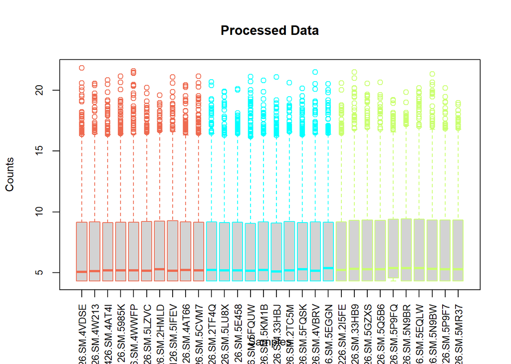

Fig. 1: Datos Normalizados.

```r
boxplot(assay(vsd), border = c(rep("coral2", 10), rep("cyan1", 10), rep("darkolivegreen1", 10)), ylab = "Counts", xlab = "Samples", main = "Processed Data", cex.main = 1.1, cex.lab = 0.9, cex.axis = 0.8, las = 3)
```

#### 3.2.3.5 Distancia entre muestras

Se calcular la distancia entre muestras y se representa esta con un gráfico heatmap. Se puede observar un mayor agrupamiento en el grupo ELI

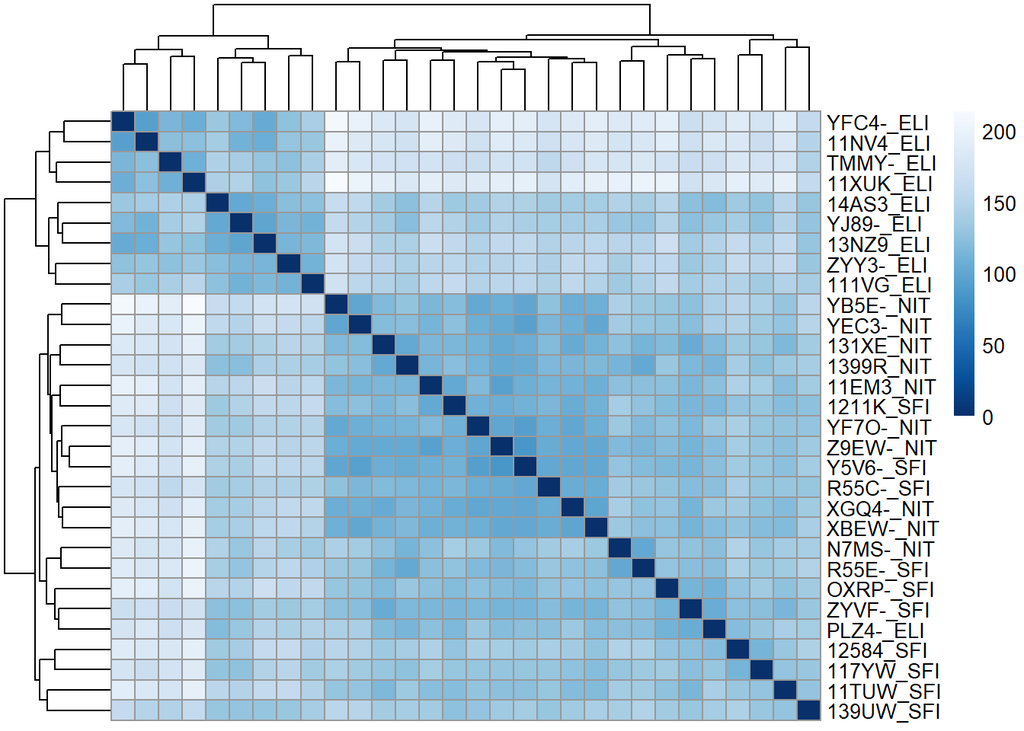

Fig. 2: Heatmap.

```r
sampleDists <- dist(t(assay(vsd)))
library("pheatmap")
library("RColorBrewer")
sampleDistMatrix <- as.matrix( sampleDists )
rownames(sampleDistMatrix) <- paste(vsd$ShortName)
colnames(sampleDistMatrix) <- NULL
colors <- colorRampPalette( rev(brewer.pal(9, "Blues")) )(255)
pheatmap(sampleDistMatrix,
         clustering_distance_rows = sampleDists,
         clustering_distance_cols = sampleDists,
         col = colors)
```

#### 3.2.3.6 Análisis de componentes principales

Se muestra un gráfico PCA. Los colores representan los diferentes grupos y se representa visualmente el agrupamiento de muestras.

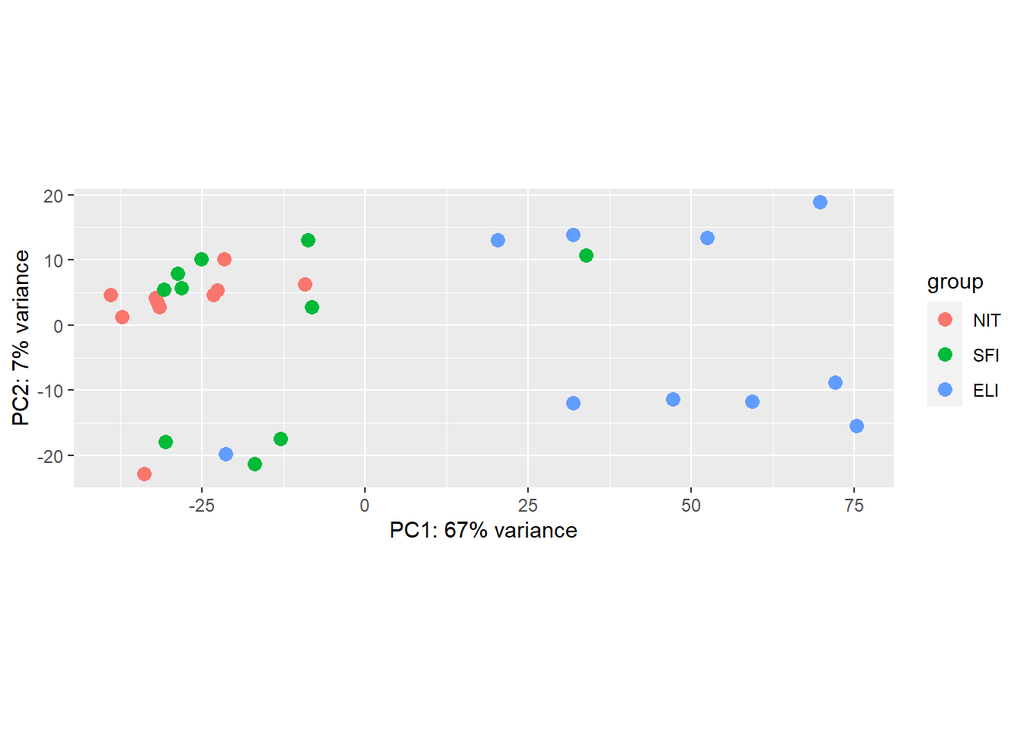

Fig. 3: Análisis de componentes principales.

```r
plotPCA(vsd, intgroup = c("Group"))
```

#### 3.2.3.7 Multidimensional Scaling

A continuación se muestra en un gráfico el análisis MDS.

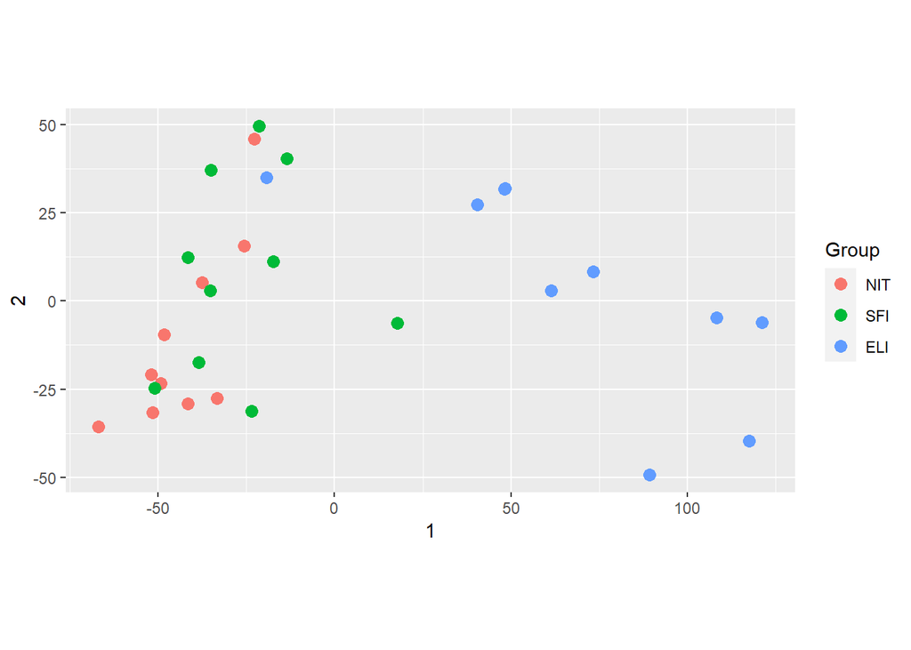

Fig. 4: Multidimensional Scaling.

```r
mds <- as.data.frame(colData(vsd))  %>%
         cbind(cmdscale(sampleDistMatrix))
ggplot(mds, aes(x = `1`, y = `2`, color = Group)) +
  geom_point(size = 3) + coord_fixed()
```

#### 3.2.3.8 Gene Clustering

Clúster de la muestra de los genes más variables. Selección de los 20 genes con la más alta variabilidad.

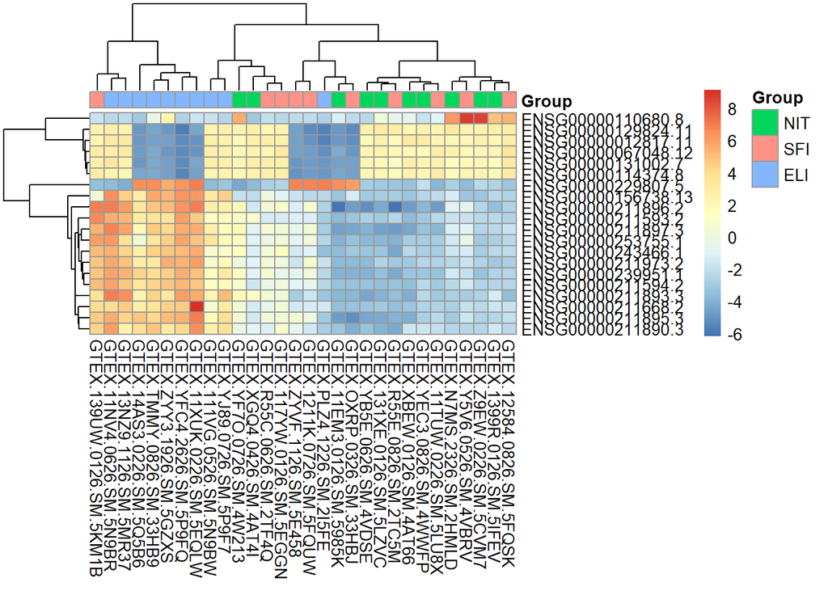

Fig. 5: Gen Clustering de los 20 genes con mas variabilidad

# 4 Resultados

## 4.1 Identificación de genes diferencialmente expresados

La identificacion de genes diferencialmente expresados se ejecuta mediante la orden DESeq, sobre el objeto DeSeqDataSet, así que no es necesario realizar nigun tipo de ajuste de los datos.

### 4.1.1 SFI vs NIT

En la comparación SFI vs NIT encontramos 271 genes sobreexpresados y 311 infraexpresados.

```r
summary(SFI_NIT_res)
```

```
##
## out of 43705 with nonzero total read count
## adjusted p-value < 0.05
## LFC > 0 (up)       : 271, 0.62%
## LFC < 0 (down)     : 311, 0.71%
## outliers [1]       : 0, 0%
## low counts [2]     : 23727, 54%
## (mean count < 19)
## [1] see 'cooksCutoff' argument of ?results
## [2] see 'independentFiltering' argument of ?results
```

```r
table(SFI_NIT_res$padj < 0.05)
```

```
##
## FALSE  TRUE
## 19398   582
```

```r
SFI_NIT_resSig <- subset(SFI_NIT_res, padj < 0.1)
head(SFI_NIT_resSig[ order(SFI_NIT_resSig$log2FoldChange), ])
```

```
## log2 fold change (MLE): Group SFI vs NIT
## Wald test p-value: Group SFI vs NIT
## DataFrame with 6 rows and 6 columns
##                    baseMean log2FoldChange     lfcSE      stat      pvalue
##                   <numeric>      <numeric> <numeric> <numeric>   <numeric>
## ENSG00000171195.6  162.8140       -6.15721  1.383291  -4.45113 8.54181e-06
## ENSG00000162078.7   94.0768       -3.44039  0.787613  -4.36812 1.25323e-05
## ENSG00000198074.5   58.3948       -2.60708  0.626771  -4.15955 3.18878e-05
## ENSG00000134339.4  118.4685       -2.47508  0.853518  -2.89985 3.73337e-03
## ENSG00000257017.4  257.0741       -2.39866  0.591920  -4.05234 5.07074e-05
## ENSG00000182566.8   31.8962       -2.30694  0.652429  -3.53592 4.06356e-04
##                         padj
##                    <numeric>
## ENSG00000171195.6 0.00731761
## ENSG00000162078.7 0.00731761
## ENSG00000198074.5 0.01019357
## ENSG00000134339.4 0.07858080
## ENSG00000257017.4 0.01202610
## ENSG00000182566.8 0.02819092
```

### 4.1.2 ELI vs NIT

En la comparación ELI vs NIT encontramos 5124 genes sobreexpresados y 3541 infraexpresados.

```r
summary(ELI_NIT_res)
```

```
##
## out of 43705 with nonzero total read count
## adjusted p-value < 0.05
## LFC > 0 (up)       : 5124, 12%
## LFC < 0 (down)     : 3541, 8.1%
## outliers [1]       : 0, 0%
## low counts [2]     : 11865, 27%
## (mean count < 1)
## [1] see 'cooksCutoff' argument of ?results
## [2] see 'independentFiltering' argument of ?results
```

```r
table(ELI_NIT_res$padj < 0.05)
```

```
##
## FALSE  TRUE
## 23177  8665
```

```r
ELI_NIT_resSig <- subset(ELI_NIT_res, padj < 0.1)
head(ELI_NIT_resSig[ order(ELI_NIT_resSig$log2FoldChange), ])
```

```
## log2 fold change (MLE): Group ELI vs NIT
## Wald test p-value: Group ELI vs NIT
## DataFrame with 6 rows and 6 columns
##                      baseMean log2FoldChange     lfcSE      stat      pvalue
##                     <numeric>      <numeric> <numeric> <numeric>   <numeric>
## ENSG00000110680.8  3068.62886       -6.54606  1.419707  -4.61085 4.01021e-06
## ENSG00000134443.5    58.06621       -5.47543  2.102210  -2.60461 9.19795e-03
## ENSG00000230663.1     5.13819       -5.24879  1.481981  -3.54174 3.97498e-04
## ENSG00000079689.9    89.01555       -4.71056  0.793287  -5.93802 2.88479e-09
## ENSG00000133105.3    25.65277       -4.63968  0.885241  -5.24115 1.59576e-07
## ENSG00000089225.15  297.75154       -4.59957  0.842171  -5.46156 4.71980e-08
##                           padj
##                      <numeric>
## ENSG00000110680.8  5.49928e-05
## ENSG00000134443.5  3.66285e-02
## ENSG00000230663.1  2.77143e-03
## ENSG00000079689.9  9.84539e-08
## ENSG00000133105.3  3.42862e-06
## ENSG00000089225.15 1.17688e-06
```

### 4.1.3 ELI vs SFI

En la comparación ELI vs SFI encontramos 3737 genes sobreexpresados y 2203 infraexpresados.

```r
summary(ELI_SFI_res)
```

```
##
## out of 43705 with nonzero total read count
## adjusted p-value < 0.05
## LFC > 0 (up)       : 3737, 8.6%
## LFC < 0 (down)     : 2203, 5%
## outliers [1]       : 0, 0%
## low counts [2]     : 12712, 29%
## (mean count < 1)
## [1] see 'cooksCutoff' argument of ?results
## [2] see 'independentFiltering' argument of ?results
```

```r
table(ELI_SFI_res$padj < 0.05)
```

```
##
## FALSE  TRUE
## 25055  5940
```

```r
ELI_SFI_resSig <- subset(ELI_SFI_res, padj < 0.1)
head(ELI_SFI_resSig[ order(ELI_SFI_resSig$log2FoldChange), ])
```

```
## log2 fold change (MLE): Group ELI vs SFI
## Wald test p-value: Group ELI vs SFI
## DataFrame with 6 rows and 6 columns
##                     baseMean log2FoldChange     lfcSE      stat      pvalue
##                    <numeric>      <numeric> <numeric> <numeric>   <numeric>
## ENSG00000134443.5   58.06621       -6.05312  2.102011  -2.87968 3.98081e-03
## ENSG00000100604.8  194.25145       -5.16929  1.061255  -4.87092 1.11080e-06
## ENSG00000170419.6   21.96576       -4.67480  1.078629  -4.33402 1.46410e-05
## ENSG00000230663.1    5.13819       -4.63445  1.487160  -3.11631 1.83131e-03
## ENSG00000089225.15 297.75154       -4.63433  0.842187  -5.50273 3.73965e-08
## ENSG00000253398.1    2.95560       -4.51645  1.750790  -2.57966 9.88971e-03
##                           padj
##                      <numeric>
## ENSG00000134443.5  2.56954e-02
## ENSG00000100604.8  2.83193e-05
## ENSG00000170419.6  2.59610e-04
## ENSG00000230663.1  1.40334e-02
## ENSG00000089225.15 1.40497e-06
## ENSG00000253398.1  5.11910e-02
```

### 4.1.4 Volcano Plots

Se puede ver que tanto ELI vs NIT como ELI vs SFI presentan muchos genes sobreexpresados y infraexpresados. En cambio en SFI vs NIT presentan una cantidad muy menor. Parece indicar que hay poca diferencia entre los tejidos SFI y NIT, puesto que no hay mucha variación en los genes diferencialmente expresados.

Volcano plot SFI vs NIT

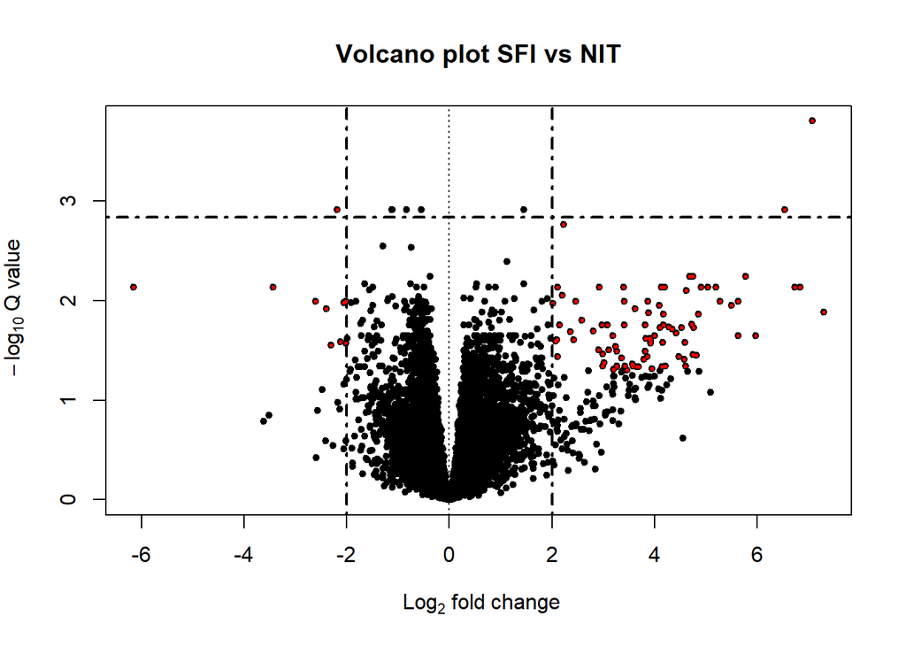

Fig. 6: Volcano plot SFI vs NIT

Volcano plot ELI vs NIT

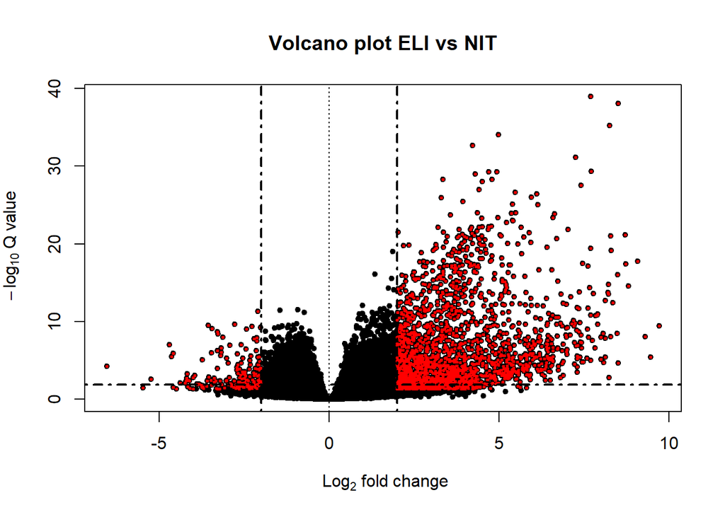

Fig. 7: Volcano plot ELI vs NIT

Volcano plot ELI vs SFI

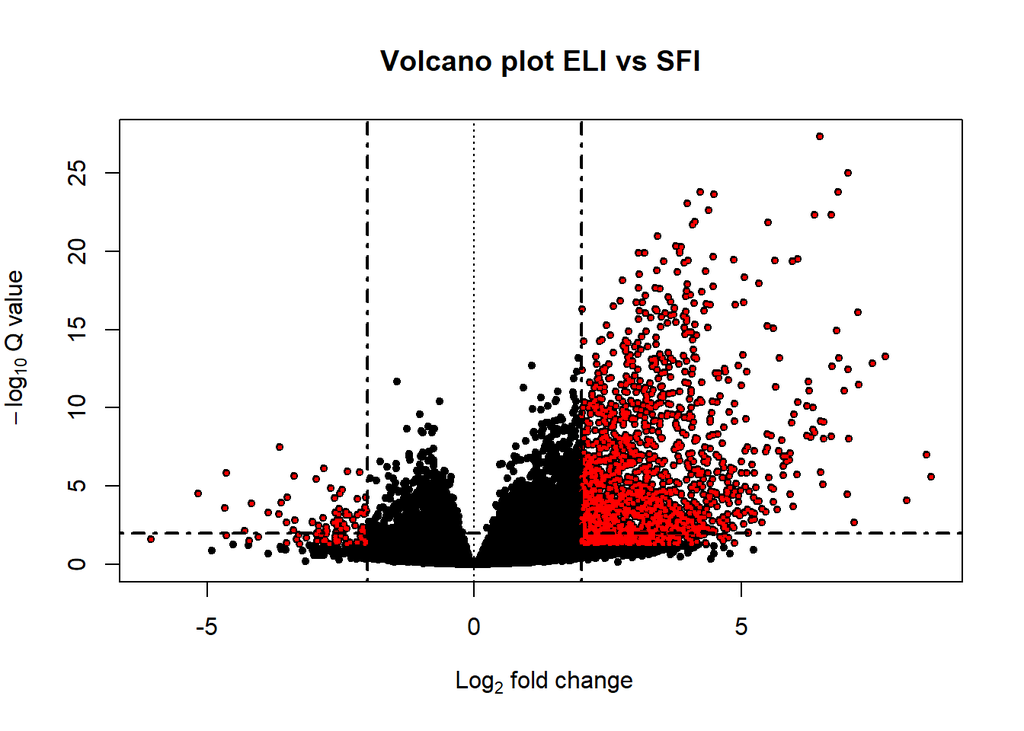

Fig. 8: Volcano plot ELI vs SFI

## 4.2 Anotación de los resultados

Para que se puedan interpretar mejor los resultados se procede a la anotación con ENSEMBL de estos.

### 4.2.1 SFI vs NIT

```r
head(SFI_NIT_resOrdenado)
```

```
## log2 fold change (MLE): Group SFI vs NIT
## Wald test p-value: Group SFI vs NIT
## DataFrame with 6 rows and 8 columns
##                  baseMean log2FoldChange     lfcSE      stat      pvalue
##                 <numeric>      <numeric> <numeric> <numeric>   <numeric>
## ENSG00000224373 2286.2474       7.077361  1.226284   5.77139 7.86210e-09
## ENSG00000104823 6610.9582      -0.833104  0.159060  -5.23767 1.62620e-07
## ENSG00000087842  988.1823      -1.116237  0.215845  -5.17148 2.32243e-07
## ENSG00000261737   38.1621      -1.123282  0.217959  -5.15364 2.55473e-07
## ENSG00000211640 1311.6531       6.543468  1.296793   5.04588 4.51431e-07
## ENSG00000205959  329.6110       1.453833  0.288323   5.04237 4.59802e-07
##                        padj      symbol      entrez
##                   <numeric> <character> <character>
## ENSG00000224373 0.000157085          NA          NA
## ENSG00000104823 0.001223311        ECH1        1891
## ENSG00000087842 0.001223311         PIR        8544
## ENSG00000261737 0.001223311   CLCA4-AS1   105378828
## ENSG00000211640 0.001223311          NA          NA
## ENSG00000205959 0.001223311          NA          NA
```

### 4.2.2 ELI vs NIT

```r
head(ELI_NIT_resOrdenado)
```

```
## log2 fold change (MLE): Group ELI vs NIT
## Wald test p-value: Group ELI vs NIT
## DataFrame with 6 rows and 8 columns
##                  baseMean log2FoldChange     lfcSE      stat      pvalue
##                 <numeric>      <numeric> <numeric> <numeric>   <numeric>
## ENSG00000167483   913.045        7.70156  0.552504   13.9394 3.65058e-44
## ENSG00000156738  5651.751        8.50562  0.618636   13.7490 5.16437e-43
## ENSG00000177455  1238.584        8.25588  0.623627   13.2385 5.25992e-40
## ENSG00000104894  2759.852        4.98036  0.382810   13.0100 1.07340e-38
## ENSG00000072818  2761.117        4.22543  0.331768   12.7361 3.72503e-37
## ENSG00000269404   404.110        7.24228  0.581509   12.4543 1.32547e-35
##                        padj      symbol      entrez
##                   <numeric> <character> <character>
## ENSG00000167483 1.16242e-39      NIBAN3      199786
## ENSG00000156738 8.22220e-39       MS4A1         931
## ENSG00000177455 5.58288e-36        CD19         930
## ENSG00000104894 8.54482e-35        CD37         951
## ENSG00000072818 2.37225e-33       ACAP1        9744
## ENSG00000269404 7.03429e-32        SPIB        6689
```

```r
head(ELI_SFI_resOrdenado)
```

```
## log2 fold change (MLE): Group ELI vs NIT
## Wald test p-value: Group ELI vs NIT
## DataFrame with 6 rows and 8 columns
##                  baseMean log2FoldChange     lfcSE      stat      pvalue
##                 <numeric>      <numeric> <numeric> <numeric>   <numeric>
## ENSG00000167483   913.045        7.70156  0.552504  13.93939 3.65058e-44
## ENSG00000177455  1238.584        8.25588  0.623627  13.23848 5.25992e-40
## ENSG00000104894  2759.852        4.98036  0.382810  13.01000 1.07340e-38
## ENSG00000156738  5651.751        8.50562  0.618636  13.74899 5.16437e-43
## ENSG00000165178   156.996        3.78086  0.400840   9.43232 4.01104e-21
## ENSG00000102879  4007.359        3.82655  0.366708  10.43487 1.71845e-25
##                        padj      symbol      entrez
##                   <numeric> <character> <character>
## ENSG00000167483 1.16242e-39      NIBAN3      199786
## ENSG00000177455 5.58288e-36        CD19         930
## ENSG00000104894 8.54482e-35        CD37         951
## ENSG00000156738 8.22220e-39       MS4A1         931
## ENSG00000165178 1.13026e-18       NCF1C      654817
## ENSG00000102879 1.33461e-22      CORO1A       11151
```

## 4.3 Análisis de significación Biológica

```r
## Bimap interface:
x <- org.Hs.egGO
mapped_genes2GO <- mappedkeys(x)
y <- org.Hs.egPATH
mapped_genes2KEGG <- mappedkeys(y)
universe <- union(mapped_genes2GO , mapped_genes2KEGG)
```

Se ha usado el paquete Reactome para realizar los analisis de Gene Enrichment seleccionando aquellos genes con un p-valor menor a 0.05. Se procede a realizar dos gráficos por compararción. El primero, un barplot con las 10 vías celulares más significativamente enriquecidas Un segundo, un cnetplot con la red de las vías y los genes relacionados.

### 4.3.1 SFI vs NIT

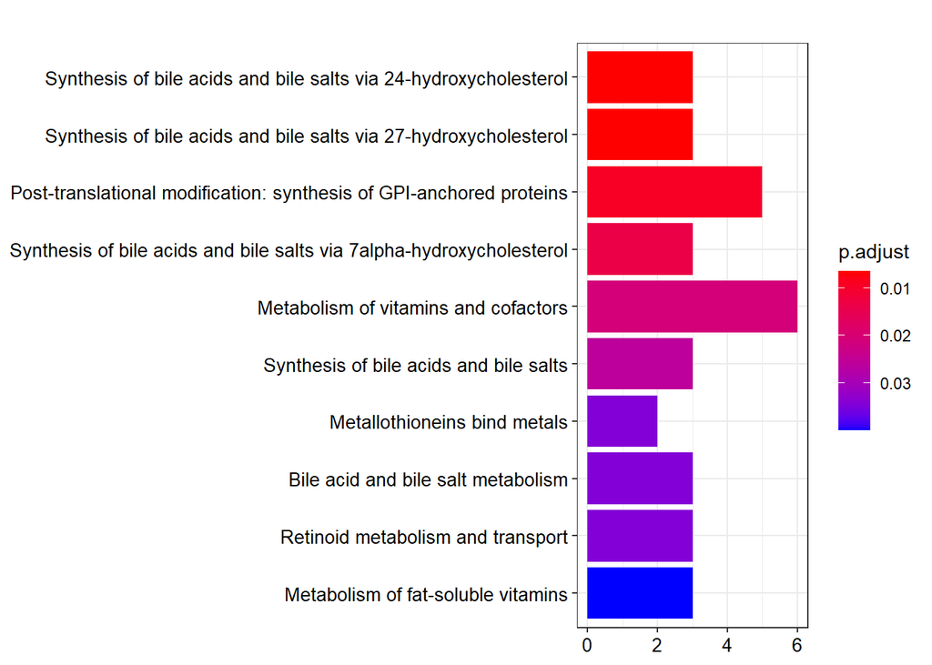

Fig. 9: Barplot SFI v NIT

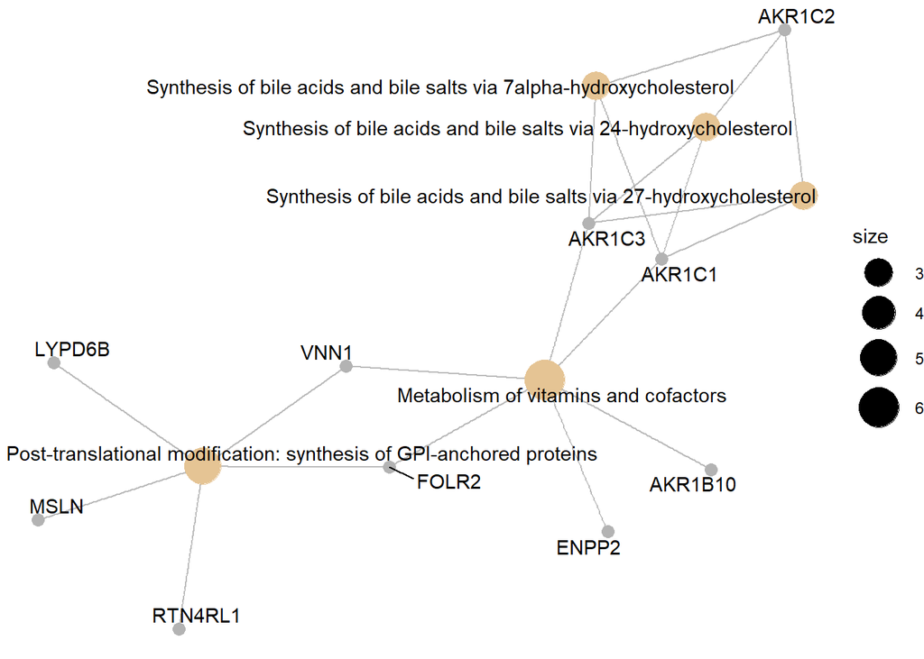

Fig. 10: Red SFI vs NIT

### 4.3.2 ELI vs NIT

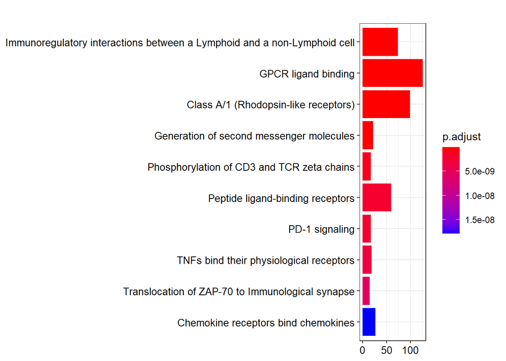

Fig. 11: Barplot ELI vs NIT

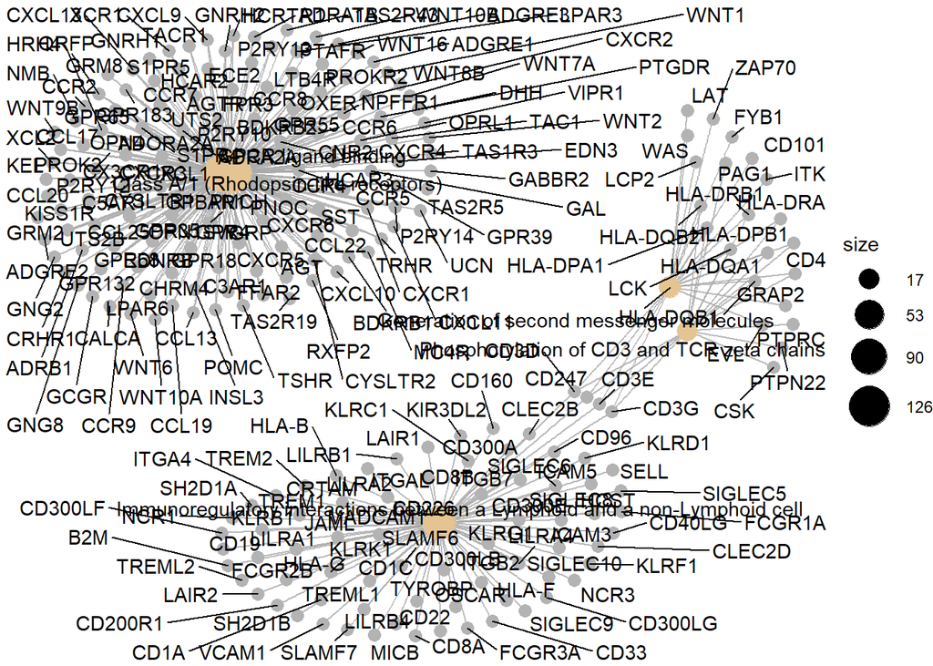

Fig. 12: Red ELI vs NIT

### 4.3.3 ELI vs SFI

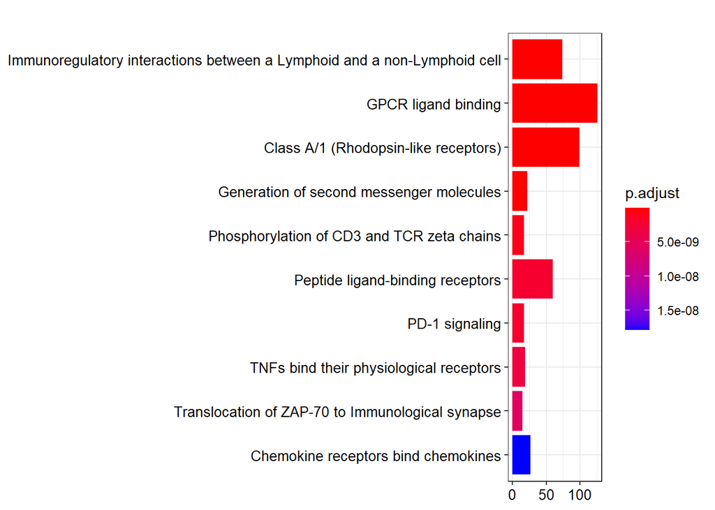

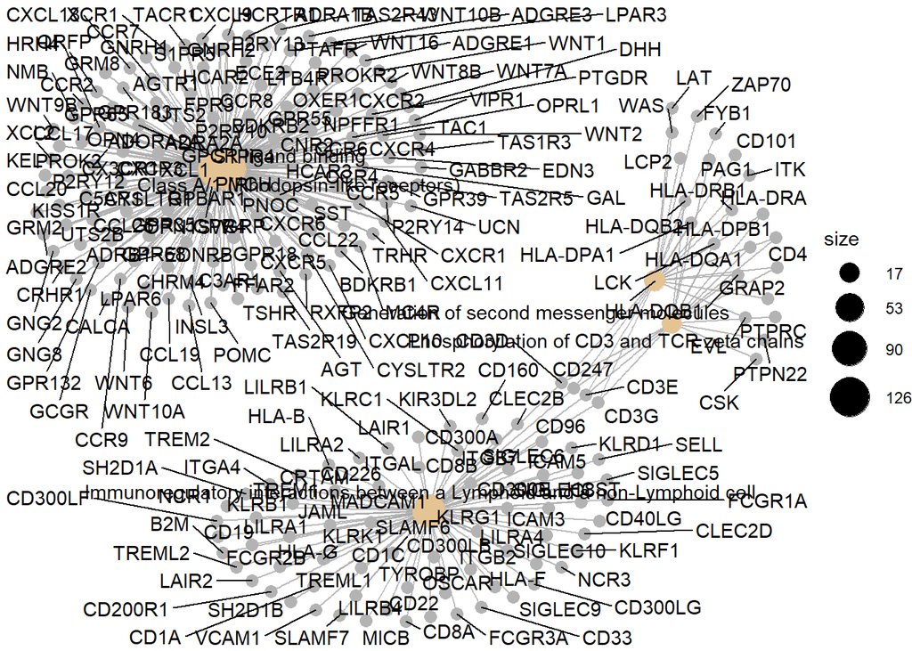

# 5 Discusión

A nivel técnico para el análisis de datos del estudio no se consideran limitaciones en ninguno de los procedimientos realizados. Por otro lado, se considera de vital importancia la adecuada comunicación con el investigador para poder realizar filtrajes y normalizaciones adecuadas.

# 6 Referencias

- Biostars - Bioinformatics explained comunity. https://www.biostars.org https://www.biostars.org/p/282295/
- Bioconductor.org. Course Materials: End-to-end RNA-Seq workflow https://www.bioconductor.org/help/course-materials/2015/CSAMA2015/lab/rnaseqCSAMA.html
- Tian Zheng - Ph.D., Columbia University 2002 http://www.stat.columbia.edu/~tzheng/
- Diego Calvo - https://www.diegocalvo.es/

# 7 Apéndice: Código

```r
if(!require(DESeq2)) BiocManager::install("DESeq2")
if(!require(pheatmap)) install.packages("pheatmap", dep=TRUE)
if(!require(RColorBrewer)) install.packages("RColorBrewer", dep=TRUE)
if(!require(ggplot2)) install.packages("ggplot2", dep=TRUE)
if(!require(org.Hs.eg.db)) BiocManager::install("org.Hs.eg.db")
if(!require(AnnotationDbi)) BiocManager::install("AnnotationDbi")

library(readr)
library(dplyr)

setwd("~/UOC_ANNA/ADO_PEC2/ADO_PEC2")
workingDir <-getwd()
dataDir <-file.path(workingDir, "data")
resultsDir <- file.path(workingDir, "results")

# se cargan los datos desde los archivos csv

counts = read.csv("./data/counts.csv",header=T,sep = ";")
target = read.csv("./data/targets.csv",header=T,sep = ",")

# se selecciona 10 muestras aleatorias de cada grupo
set.seed(1907)

target_NIT <- subset(target, target$Group == "NIT")
target_SFI <- subset(target, target$Group == "SFI")
target_ELI <- subset(target, target$Group == "ELI")


target_NIT_10 <- dplyr::sample_n(target_NIT, 10, replace = FALSE)
target_SFI_10 <- dplyr::sample_n(target_SFI, 10)
target_ELI_10 <- dplyr::sample_n(target_ELI, 10)

target_final = rbind(target_NIT_10, target_SFI_10, target_ELI_10)

target_final$Group <- factor(target_final$Group, levels = c("NIT", "SFI", "ELI"))

# Se modifica el Sample_Name para que cuadre con el formato de counts

target_final$Sample_Name <- gsub("-",".", target_final$Sample_Name)

# Se selecciona las 30 muestras correspondientes del archivo counts

library(dplyr)
count_final=counts[,c(target_final$Sample_Name)]
rownames(count_final)=counts$X


# A continuación se procede a preparar el objeto DESeqDataSet a partir de la matriz de counts.

dds <- DESeqDataSetFromMatrix(countData = count_final,colData = target_final, design = ~ Group)

# Una vez preparado el objeto DESeqDataSet, se filtran los datos

dds <- dds[rowSums(counts(dds)) > 1, ]

# Se procede a normalizar los datos usando vst

vsd <- vst(dds, blind = FALSE)

# Se procede a mostrar los datos normalizados en un boxplot

boxplot(assay(vsd), border = c(rep("coral2", 10), rep("cyan1", 10), rep("darkolivegreen1", 10)), ylab = "Counts", xlab = "Samples", main = "Processed Data", cex.main = 1.1, cex.lab = 0.9, cex.axis = 0.8, las = 3)


# Se procede a calcular la distancia entre muestras y se representa esta con un gráfico heatmap

sampleDists <- dist(t(assay(vsd)))
library("pheatmap")
library("RColorBrewer")
sampleDistMatrix <- as.matrix( sampleDists )
rownames(sampleDistMatrix) <- paste(vsd$ShortName)
colnames(sampleDistMatrix) <- NULL
colors <- colorRampPalette( rev(brewer.pal(9, "Blues")) )(255)
pheatmap(sampleDistMatrix,
         clustering_distance_rows = sampleDists,
         clustering_distance_cols = sampleDists,
         col = colors)


# Se representa visualmente el agrupamiento de muestras
plotPCA(vsd, intgroup = c("Group"))

# Analisis MDS

mds <- as.data.frame(colData(vsd))  %>%
         cbind(cmdscale(sampleDistMatrix))
ggplot(mds, aes(x = `1`, y = `2`, color = Group)) +
  geom_point(size = 3) + coord_fixed()


# Cluster de la muestra de los genes mas variables. Selección de los 20 genes con la mas alta variabilidad.

library("genefilter")
topVarGenes <- head(order(rowVars(assay(vsd)), decreasing = TRUE), 20)

mat  <- assay(vsd)[topVarGenes, ]
mat  <- mat - rowMeans(mat)
anno <- as.data.frame(colData(vsd)[, "Group"])
rownames(anno) <- rownames(colData(vsd))
colnames(anno) <- "Group"
pheatmap(mat, annotation_col = anno)


# identificacion de genes diferencialmente expresados
dds <- DESeq(dds, parallel =TRUE)


# comparación SFI vs NIT

SFI_NIT_res <- results(dds, contrast=c("Group","SFI","NIT"), alpha = 0.05)
SFI_NIT_res

summary(SFI_NIT_res)

table(SFI_NIT_res$padj < 0.05)

SFI_NIT_resSig <- subset(SFI_NIT_res, padj < 0.1)
head(SFI_NIT_resSig[ order(SFI_NIT_resSig$log2FoldChange), ])


# comparación ELI vs NIT


ELI_NIT_res <- results(dds, contrast=c("Group","ELI","NIT"), alpha = 0.05)
ELI_NIT_res

summary(ELI_NIT_res)

table(ELI_NIT_res$padj < 0.05)

ELI_NIT_resSig <- subset(ELI_NIT_res, padj < 0.1)
head(ELI_NIT_resSig[ order(ELI_NIT_resSig$log2FoldChange), ])


# comparación  ELI vs SFI

ELI_SFI_res <- results(dds, contrast=c("Group","ELI","SFI"), alpha = 0.05)
ELI_SFI_res
summary(ELI_SFI_res)

table(ELI_SFI_res$padj < 0.05)

ELI_SFI_resSig <- subset(ELI_SFI_res, padj < 0.1)
head(ELI_SFI_resSig[ order(ELI_SFI_resSig$log2FoldChange), ])


# Volcano plot SFI-NIT

SFI_NIT_res2 <- as.data.frame(SFI_NIT_res)

plot(SFI_NIT_res2$log2FoldChange, -log10(SFI_NIT_res2$padj), pch=20, main="Volcano plot SFI vs NIT", cex=1.0, xlab=bquote(~Log[2]~fold~change), ylab=bquote(~-log[10]~Q~value))
with(subset(SFI_NIT_res2, padj<0.05 & abs(log2FoldChange)>2), points(log2FoldChange, -log10(padj), pch=20, col="red", cex=0.5))
abline(v=0, col="black", lty=3, lwd=1.0)
abline(v=-2, col="black", lty=4, lwd=2.0)
abline(v=2, col="black", lty=4, lwd=2.0)
abline(h=-log10(max(SFI_NIT_res2$pvalue[SFI_NIT_res2$padj<0.05], na.rm=TRUE)), col="black", lty=4, lwd=2.0)

# Volcano plot ELI-NIT
ELI_NIT_res2 <- as.data.frame(ELI_NIT_res)

plot(ELI_NIT_res2$log2FoldChange, -log10(ELI_NIT_res2$padj), pch=20, main="Volcano plot ELI vs NIT", cex=1.0, xlab=bquote(~Log[2]~fold~change), ylab=bquote(~-log[10]~Q~value))
with(subset(ELI_NIT_res2, padj<0.05 & abs(log2FoldChange)>2), points(log2FoldChange, -log10(padj), pch=20, col="red", cex=0.5))
abline(v=0, col="black", lty=3, lwd=1.0)
abline(v=-2, col="black", lty=4, lwd=2.0)
abline(v=2, col="black", lty=4, lwd=2.0)
abline(h=-log10(max(ELI_NIT_res2$pvalue[ELI_NIT_res2$padj<0.05], na.rm=TRUE)), col="black", lty=4, lwd=2.0)

# Volcano plot ELI-SFI
ELI_SFI_res2 <- as.data.frame(ELI_SFI_res)

plot(ELI_SFI_res2$log2FoldChange, -log10(ELI_SFI_res2$padj), pch=20, main="Volcano plot ELI vs SFI", cex=1.0, xlab=bquote(~Log[2]~fold~change), ylab=bquote(~-log[10]~Q~value))
with(subset(ELI_SFI_res2, padj<0.05 & abs(log2FoldChange)>2), points(log2FoldChange, -log10(padj), pch=20, col="red", cex=0.5))
abline(v=0, col="black", lty=3, lwd=1.0)
abline(v=-2, col="black", lty=4, lwd=2.0)
abline(v=2, col="black", lty=4, lwd=2.0)
abline(h=-log10(max(ELI_SFI_res2$pvalue[ELI_SFI_res2$padj<0.05], na.rm=TRUE)), col="black", lty=4, lwd=2.0)
```

```r
# Anotación de los resultados con ENSEMBL

# SFI-NIT
# normalizamos los nombres de las filas para poder cuadrarlos
rownames(SFI_NIT_res)<- gsub("\\..*","", rownames(SFI_NIT_res))

library("AnnotationDbi")
SFI_NIT_res$symbol <- mapIds(org.Hs.eg.db,
                           keys = rownames(SFI_NIT_res),
                           column = "SYMBOL",
                           keytype = "ENSEMBL",
                           multiVals="first")
SFI_NIT_res$entrez  <- mapIds(org.Hs.eg.db,
                           keys = rownames(SFI_NIT_res),
                           column = "ENTREZID",
                           keytype = "ENSEMBL",
                           multiVals="first")
SFI_NIT_resOrdenado <- SFI_NIT_res[order(SFI_NIT_res$pvalue),]

head(SFI_NIT_resOrdenado)


# ELI-NIT

# normalizamos los nombres de las filas para poder cuadrarlos
rownames(ELI_NIT_res)<- gsub("\\..*","", rownames(ELI_NIT_res))

library("AnnotationDbi")
ELI_NIT_res$symbol <- mapIds(org.Hs.eg.db,
                           keys = rownames(ELI_NIT_res),
                           column = "SYMBOL",
                           keytype = "ENSEMBL",
                           multiVals="first")
ELI_NIT_res$entrez  <- mapIds(org.Hs.eg.db,
                           keys = rownames(ELI_NIT_res),
                           column = "ENTREZID",
                           keytype = "ENSEMBL",
                           multiVals="first")
ELI_NIT_resOrdenado <- ELI_NIT_res[order(ELI_NIT_res$pvalue),]

head(ELI_NIT_resOrdenado)


# ELI-SFI

# normalizamos los nombres de las filas para poder cuadrarlos
rownames(ELI_SFI_res)<- gsub("\\..*","", rownames(ELI_SFI_res))

library("AnnotationDbi")
ELI_SFI_res$symbol <- mapIds(org.Hs.eg.db,
                           keys = rownames(ELI_SFI_res),
                           column = "SYMBOL",
                           keytype = "ENSEMBL",
                           multiVals="first")
ELI_SFI_res$entrez  <- mapIds(org.Hs.eg.db,
                           keys = rownames(ELI_SFI_res),
                           column = "ENTREZID",
                           keytype = "ENSEMBL",
                           multiVals="first")
ELI_SFI_resOrdenado <- ELI_NIT_res[order(ELI_SFI_res$pvalue),]

head(ELI_SFI_resOrdenado)

# Análisis de significación Biológica

## Bimap interface:
x <- org.Hs.egGO
mapped_genes2GO <- mappedkeys(x)
y <- org.Hs.egPATH
mapped_genes2KEGG <- mappedkeys(y)
universe <- union(mapped_genes2GO , mapped_genes2KEGG)


# Analisis de enriquecimiento de Pathway usando ReactomePA
# SFI-NIT

library(ReactomePA)

SFI_NIT_res2 <- as.data.frame(SFI_NIT_res)

genSFI_NIT_res = c(SFI_NIT_res2[SFI_NIT_res2$padj < 0.05 & SFI_NIT_res2$log2FoldChange > 1, "symbol"], SFI_NIT_res2[SFI_NIT_res2$padj < 0.05 & SFI_NIT_res2$log2FoldChange < -1, "symbol"])

selectedIDs = mapIds(org.Hs.eg.db, genSFI_NIT_res, 'ENTREZID', 'SYMBOL')
enrich.resultSFI_NIT <- enrichPathway(selectedIDs, pvalueCutoff = 0.05, readable = T, organism = "human", universe = universe)

barplot(enrich.resultSFI_NIT, showCategory = 10, font.size = 10)

cnetplot(enrich.resultSFI_NIT, categorySize = "geneNum", schowCategory = 15, vertex.label.cex = 0.75)


# ELI-NIT

library(ReactomePA)

ELI_NIT_res2 <- as.data.frame(ELI_NIT_res)

genELI_NIT_res = c(ELI_NIT_res2[ELI_NIT_res2$padj < 0.05 & ELI_NIT_res2$log2FoldChange > 1, "symbol"], ELI_NIT_res2[ELI_NIT_res2$padj < 0.05 & ELI_NIT_res2$log2FoldChange < -1, "symbol"])

selectedIDs = mapIds(org.Hs.eg.db, genELI_NIT_res, 'ENTREZID', 'SYMBOL')
enrich.resultELI_NIT <- enrichPathway(selectedIDs, pvalueCutoff = 0.05, readable = T, organism = "human", universe = universe)

barplot(enrich.resultELI_NIT, showCategory = 10, font.size = 10)

cnetplot(enrich.resultELI_NIT, categorySize = "geneNum", schowCategory = 15, vertex.label.cex = 0.75)


# ELI-SFI

library(ReactomePA)

ELI_SFI_res2 <- as.data.frame(ELI_SFI_res)

genELI_SFI_res = c(ELI_SFI_res2[ELI_SFI_res2$padj < 0.05 & ELI_SFI_res2$log2FoldChange > 1, "symbol"], ELI_SFI_res2[ELI_SFI_res2$padj < 0.05 & ELI_SFI_res2$log2FoldChange < -1, "symbol"])

selectedIDs = mapIds(org.Hs.eg.db, genELI_NIT_res, 'ENTREZID', 'SYMBOL')
enrich.resultELI_SFI <- enrichPathway(selectedIDs, pvalueCutoff = 0.05, readable = T, organism = "human", universe = universe)

barplot(enrich.resultELI_SFI, showCategory = 10, font.size = 10)

cnetplot(enrich.resultELI_SFI, categorySize = "geneNum", schowCategory = 15, vertex.label.cex = 0.75)


# Exportamos resultados


pdf(file = "./results/PCA.pdf")
plotPCA(vsd, intgroup = c("Group"))
dev.off()

pdf(file = "./results/MDS.pdf")
ggplot(mds, aes(x = `1`, y = `2`, color = Group)) + geom_point(size = 3) + coord_fixed()
dev.off()

pdf(file="./results/heatmapClustering.pdf")
pheatmap(sampleDistMatrix, clustering_distance_rows = sampleDists, clustering_distance_cols = sampleDists, col = colors)
dev.off()

pdf(file="./results/BoxPlotVSD.pdf")
boxplot(assay(vsd), border = c(rep("coral2", 10), rep("cyan1", 10), rep("darkolivegreen1", 10)), ylab = "Counts", xlab = "Samples", main = "Processed Data", cex.main = 1.1, cex.lab = 0.9, cex.axis = 0.8, las = 3)
dev.off()

pdf(file="./results/VolcanoPlotSFI-NIT.pdf")
plot(SFI_NIT_res2$log2FoldChange, -log10(SFI_NIT_res2$padj), pch=20, main="Volcano plot SFI vs NIT", cex=1.0, xlab=bquote(~Log[2]~fold~change), ylab=bquote(~-log[10]~Q~value))
with(subset(SFI_NIT_res2, padj<0.05 & abs(log2FoldChange)>2), points(log2FoldChange, -log10(padj), pch=20, col="red", cex=0.5))
abline(v=0, col="black", lty=3, lwd=1.0)
abline(v=-2, col="black", lty=4, lwd=2.0)
abline(v=2, col="black", lty=4, lwd=2.0)
abline(h=-log10(max(SFI_NIT_res2$pvalue[SFI_NIT_res2$padj<0.05], na.rm=TRUE)), col="black", lty=4, lwd=2.0)
dev.off()


pdf(file="./results/VolcanoPlotELI-NIT.pdf")
plot(ELI_NIT_res2$log2FoldChange, -log10(ELI_NIT_res2$padj), pch=20, main="Volcano plot ELI vs NIT", cex=1.0, xlab=bquote(~Log[2]~fold~change), ylab=bquote(~-log[10]~Q~value))
with(subset(ELI_NIT_res2, padj<0.05 & abs(log2FoldChange)>2), points(log2FoldChange, -log10(padj), pch=20, col="red", cex=0.5))
abline(v=0, col="black", lty=3, lwd=1.0)
abline(v=-2, col="black", lty=4, lwd=2.0)
abline(v=2, col="black", lty=4, lwd=2.0)
abline(h=-log10(max(ELI_NIT_res2$pvalue[ELI_NIT_res2$padj<0.05], na.rm=TRUE)), col="black", lty=4, lwd=2.0)
dev.off()
```

```r
pdf(file="./results/VolcanoPlotELI-SFI.pdf")
plot(ELI_SFI_res2$log2FoldChange, -log10(ELI_SFI_res2$padj), pch=20, main="Volcano plot ELI vs SFI", cex=1.0, xlab=bquote(~Log[2]~fold~change), ylab=bquote(~-log[10]~Q~value))
with(subset(ELI_SFI_res2, padj<0.05 & abs(log2FoldChange)>2), points(log2FoldChange, -log10(padj), pch=20, col="red", cex=0.5))
abline(v=0, col="black", lty=3, lwd=1.0)
abline(v=-2, col="black", lty=4, lwd=2.0)
abline(v=2, col="black", lty=4, lwd=2.0)
abline(h=-log10(max(ELI_SFI_res2$pvalue[ELI_SFI_res2$padj<0.05], na.rm=TRUE)), col="black", lty=4, lwd=2.0)
dev.off()

pdf(file="./results/Gene_Clustering.pdf")
pheatmap(mat, annotation_col = anno)
dev.off()

pdf(file="./results/enrichResultSFI_NIT.pdf")
barplot(enrich.resultSFI_NIT, showCategory = 10, font.size = 10)
dev.off()

pdf(file="./results/enrichResultELI_NIT.pdf")
barplot(enrich.resultELI_NIT, showCategory = 10, font.size = 10)
dev.off()

pdf(file="./results/enrichResultELI_SFI.pdf")
barplot(enrich.resultELI_SFI, showCategory = 10, font.size = 10)
dev.off()


pdf(file="./results/enrichCNETResultSFI_NIT.pdf")
cnetplot(enrich.resultSFI_NIT, categorySize = "geneNum", schowCategory = 15, vertex.label.cex = 0.75)
dev.off()

pdf(file="./results/enricCNEThResultELI_NIT.pdf")
cnetplot(enrich.resultELI_NIT, categorySize = "geneNum", schowCategory = 15, vertex.label.cex = 0.75)
dev.off()

pdf(file="./results/enrichCNETResultELI_SFI.pdf")
cnetplot(enrich.resultELI_SFI, categorySize = "geneNum", schowCategory = 15, vertex.label.cex = 0.75)
dev.off()

SFI_NIT_resOrdenadoDf <- as.data.frame(SFI_NIT_resOrdenado)
write.csv(SFI_NIT_resOrdenadoDf, file = "./results/Resultados_SFI_NIT_resOrdenado.csv")

ELI_NIT_resOrdenadoDf <- as.data.frame(ELI_NIT_resOrdenado)
write.csv(ELI_NIT_resOrdenadoDf, file = "./results/Resultados_ELI_NIT_resOrdenado.csv")

ELI_SFI_resOrdenadoDf <- as.data.frame(ELI_SFI_resOrdenado)
write.csv(ELI_SFI_resOrdenadoDf, file = "./results/Resultados_ELI_SFI_resOrdenado.csv")

write.csv(enrich.resultSFI_NIT@result, "./results/Enrich_Resultados_SFI_NIT.csv", row.names = FALSE, quote = FALSE)

write.csv(enrich.resultELI_NIT@result, "./results/Enrich_Resultados_ELI_NIT.csv", row.names = FALSE, quote = FALSE)

write.csv(enrich.resultELI_SFI@result, "./results/Enrich_Resultados_ELI_SFI.csv", row.names = FALSE, quote = FALSE)
```